# Language Models for Mathematicians

# 2. Universal Approximation Theorems

A neural network is defined by its weight matrices $W_i$ and bias vectors $b_i$, collectively known as parameters and denoted by $P = (W_1, W_2, \ldots, W_L, b_1, \ldots, b_L)$. These parameters can be thought long vector of dimension $K$ for some $K \in \mathbb{N}$, representing a point $P$ in $\mathbb{R}^K$. Each point corresponds uniquely to a neural network instance, denoted $NN_P$, which is structured according to the network's fixed architecture. This parameter-to-network mapping can be expressed as: $$ P \mapsto NN_P $$ The primary task of machine learning is to select the parameter $P$ that make $NN_P$ best approximates the function of interest. This point of view allow us to see ML is a techique of function approximation much like that of Fourier series and Taylor expansion. One obvious question is what kind of function can be approximated by neural networks. The answer of this question coming from universal approximation theorems which we are now turn to. First, we look at a theorem due to G. Cybenko in his paper **[Approximation by Superpositions of a Sigmoidal Function](https://web.njit.edu/~usman/courses/cs677/10.1.1.441.7873.pdf)**

**Universal Approximation Theorem, G. Cybenko:** The space $ N_2 = \bigcup_{N=1}^{\infty} \left\{ \sum_{i}^N\alpha_i \sigma(y_i^T x + b_i) \mid y_i \in \mathbb{R}^d \right\} $ is dense in $ \mathcal{C}(I_d, \mathbb{R}) $, where $ \sigma: \mathbb{R} \to \mathbb{R} $ is a fixed discriminatory function, to be defined below, and $I_d$ is the unit cube in dimension $d$.

**Definition** We say that $\sigma$ is *discriminatory* if for a measure $\mu \in M(I_n)$, $$ \int_{I_n} \sigma(y^T x + \theta) \, d\mu(x) = 0 $$ for all $y \in \mathbb{R}^n$ and $\theta \in \mathbb{R}$ implies that $\mu = 0$.

**Proof**

Note that $ N_2 = \bigcup_{N=1}^{\infty} \left\{ \sum_{i}^N\alpha_i \sigma(y_i^T x + b_i) \mid y_i \in \mathbb{R}^d \right\} $ is a linear subspace of $\mathcal{C}(I_d,\mathbb{R})$. Assume it is not dense, then its closure $\bar{N_2}$ is a proper Banach subspace of $\mathcal{C}$. We can define a linear functional $\ell:\bar{N_2}\to \mathbb{R}$ to be zero. Since $\bar{N_2}$ is a proper subspace, the Hanh-Banach's theorem allows us to extend $\ell$ to all of $\mathcal{C}$ such that $\ell(f)=0$ if $f\in \bar{N_2}$ and $\ell(f)\neq 0$ for some $f\notin \bar{N_2}$. In particular, there exist $f_0\in \mathcal{C}$ such that $\ell(f_0)\neq 0$.

Now follow Rieze-Markov-Kakutani representation theorem, we know there exist a positive Borel's measure $\mu$ on $I_d$ such that $$ \ell(f)=\int fd\mu $$ for all $f\in \mathcal{C}$. In particular $\int \sigma(y_i^Tx+b)d\mu=0$ for all $y\in \mathbb{R}^d$ and $b\in\mathbb{R}$. But $\sigma$ is discriminatory, this implies $\mu=0$. However, we know that $\int f_0d\mu=\ell(f_0)\neq 0$, this is a contradiction.

The next stage of the proof is to prove that the activation functions we have above are discriminatory with respect to the Lebesgue measure. This is true but we won't be proving it here.

We can equip the space $\mathcal{C}(I_d,\mathbb{R})$ with the $L^pp$ norm, and there are similar results by Kurt Hornik in 1990 in his paper **[Approximation capabilities of multilayer feedforward networks](https://www.sciencedirect.com/science/article/pii/089360809190009T)**.

**Theorem, K. Hornik:** The space $ N_2 = \bigcup_{N=1}^{\infty} \left\{ \sum_{i}^N\alpha_i \sigma(y_i^T x + b_i) \mid y_i \in \mathbb{R}^d \right\} $ is dense in the space of $\mathcal{C}(I_d,\mathbb{R})$ when $\mathcal{C}$ is equipped with the $L^p$ norm with $1\leq p\leq \infty$ and $\sigma$ is a continuous, bounded and non-constant function.

## 2.1 Implementation

Let's consider the task of finding a two-layer neural network to approximate $\cos(x)$ for $x \in [-10,10]$ with respect to the $L^2$ norm. Given $\varepsilon > 0$, the Universal Approximation Theorem tells us that there exists a neural network which is $\varepsilon$-close to $\cos(x)$ on this interval in the $L^2$ norm. The question then is which neural network? Unfortunately, there is no straightforward way to identify it directly. What we can do is fix an architecture for the network and then search for the parameters $P$ that work best. We start with a random initial guess for $P$ and use gradient descent to iteratively improve this guess.

Let's set this mathematically. As an example, first, we select the architecture by setting the first layer to have dimension $13$ and the second layer to have dimension $5$. This means we are looking for a function $$ NN_P(x) = W_3(\sigma(W_2\sigma(W_1x+b_1)+b_2))+b_3 $$ where $W_1$ is a matrix that takes $\mathbb{R}^1$ to $\mathbb{R}^{13}$, $W_2$ is a matrix taking $\mathbb{R}^{13}$ to $\mathbb{R}^5$, $W_3$ is a matrix that takes $\mathbb{R}^5$ back to $\mathbb{R}$, and $b_1 \in \mathbb{R}^{13}, b_2 \in \mathbb{R}^5$ and $b_3 \in \mathbb{R}$. In this case, $P = (W_1, W_2, W_3, b_1, b_2, b_3)$ is a point in $\mathbb{R}^{13 \cdot 1 + 13 \cdot 5 + 5 \cdot 1 + 13 + 5 + 1=102}$.

Given $P \in \mathbb{R}^{102}$, we construct a function $NN_P(x)$ to approximate the cosine function. The error of this approximation is measured by the loss function, defined as: $$ \text{loss}(P) = \int_{-10}^{10} (\cos(x) - NN_P(x))^2 \, dx $$ The task is to optimize $\text{loss}: \mathbb{R}^{102} \to \mathbb{R}$. Of course we can't hope to find $P$ that truly is the minimum since the dimension is so large. What we can hope for is to find $P$ such that $\text{loss}(P)<\varepsilon$ for an acceptable $\varepsilon>0$.

Let's summarize where we are now. We have a dataset $D$. For each data point $x_i \in [-10,10]$, we can evaluate the point-wise loss for each parameter set $P$. Averaging these, we obtain the empirical loss: $$ \text{loss}_D(P) = \frac{\sum_{i=1}^N |\cos(x_i) - NN_P(x_i)|^2}{N} $$ While this empirical loss is computable, it remains challenging to optimize using critical points method. A method commonly used for this optimization is called gradient descent.

# 3. Gradient Descent Algorithm

Let's remind ourselves what gradient descent is. Consider $f: \mathbb{R}^d \to \mathbb{R}$. The goal is to find a point $P$ where $f(P)$ is the global minimum of $f$. The gradient descent algorithm suggests the following steps:

1. Start at a point $P_0$.
2. Compute the gradient $\nabla f(P_0)$.
3. Take a small step $\eta>0$ in the direction opposite to the gradient, i.e., $P_1 = P_0 - \eta \nabla f(P_0)$.
4. Repeat the above process.

The number $\eta$ is known as the learning rate. The reason we move in the direction opposite to the gradient is that the function decreases fastest in this direction.

We now state and prove that if $f$ is a nice function, the gradient decent algorithm will converge to a minimum. Note that most function we encounter in machine learning are far from being nice.

**Theorem** Let $f:\mathbb{R}^d\to \mathbb{R}$ be a strongly convex, bounded below, non-constant differentiable function where the derivative $Df:\mathbb{R}^d\to \mathbb{R}^d$ of $f$ is Lipschitz. Then $f$ has a unique minimum, we denoted it by $P_c$. Moreover, for $\eta$ sufficiently small, the sequence $$ P_{n+1}=P_n-\eta \nabla f(P_n) $$ converges to $P_c$ for any initial point $P_0$.

**Definition** Let $f:\mathbb{R}^d\to \mathbb{R}$. We say $f$ is convex if for all $P,Q\in \mathbb{R}^d$ we have $$ f(\lambda P+(1-\lambda Q)\leq \lambda f(P)+(1-\lambda)f(Q), $$ which implies $$f(P)-f(Q)\geq \nabla f(Q)^T(P-Q)$$ if $f$ is differentiable. A function $f$ is strongly convex if there exist $H>0$ such that $$ f(P)\leq f(Q)+\nabla f(Q)^T(P-Q)+H/2\|P-Q\|^2. $$ And $F:\mathbb{R}^d\to \mathbb{R}^d$ is Lipschitz if there exist $L>0$ such that $$ \|F(P)-\nabla F\|\leq L\|P-Q\| $$ for any $P,Q\in \mathbb{R}^d$.

*Note:* If $f$ is convex, with $Df$ being Lipschitz doesn't imply uniqueness of a minimum, $f(x,y)=x^2$ is an example of such function.

**Proof** Recall that the gradient descent update rule is given by: $$ P_{k+1} = P_k - \eta \nabla f(P_k) $$ where $ \eta $ is the step size (learning rate). We aim to show that this sequence $ P_k $ converges to the global minimum.

Since $ f $ is strongly convex, there exists a constant $ \mu > 0 $ such that for any $ P $ and $ Q $, $$ f(Q) \geq f(P) + \nabla f(P)^T (Q - P) + \frac{\mu}{2} \| P - Q \|^2. $$

Using the Lipschitz continuity of $ \nabla f $, we also have that there exists $ L > 0 $ such that: $$ \| \nabla f(P) - \nabla f(Q) \| \leq L \| P - Q \|. $$

Now, consider the difference in function values at consecutive points in the gradient descent sequence: $$ f(P_{k+1}) \leq f(P_k) + \nabla f(P_k)^T (P_{k+1} - P_k) + \frac{L}{2} \| P_{k+1} - P_k \|^2. $$

Substitute $ P_{k+1} = P_k - \eta \nabla f(P_k) $ into this inequality: $$ f(P_{k+1}) \leq f(P_k) - \eta \| \nabla f(P_k) \|^2 + \frac{L \eta^2}{2} \| \nabla f(P_k) \|^2. $$ This simplifies to: $$ f(P_{k+1}) \leq f(P_k) - \left( \eta - \frac{L \eta^2}{2} \right) \| \nabla f(P_k) \|^2. $$ For convergence, we require $ \eta $ to satisfy $ \eta < \frac{2}{L} $. In this case, the term $ \eta - \frac{L \eta^2}{2} $ is positive, and thus $ f(P_{k+1}) \leq f(P_k) $, implying that the function values decrease with each iteration of gradient descent.

Since $ f(P) $ is bounded below, the sequence $ f(P_k) $ converges, say to $m_f$.

The equation $$ f(P_{k+1}) \leq f(P_k) - \left( \eta - \frac{L \eta^2}{2} \right) \| \nabla f(P_k) \|^2. $$ can be rewrite as $$ 0<\left( \eta - \frac{L \eta^2}{2} \right) \|P_{k+1}-P_k \|^2 \leq f(P_k)-f(P_{k+1}) $$

Sum up above expression from $k=0$ to $N$, we obtain

$$ 0<\left( \eta - \frac{L \eta^2}{2} \right) \sum_{k=1}^{N}\|P_{k+1}-P_k \|^2 \leq f(P_0)-f(P_{N})<f(P_0)-m_f $$

This means the series $\sum_{k=1}^{N}\|P_{k+1}-P_k \|^2$ is convergent, and therefore $\{P_k\}_{k=1}^{\infty}$ must converges to a point, called this point $P_c$. And this we leave it for keen readers to entertain themselves to prove uniqueness.

## 3.1 Stochastic Gradient Descent

Consider the problem of training a neural network $NN(x)$ to learn a function $F:\mathbb{R}\to \mathbb{R}$. We don't know $F$ but we have $N$ samples of it, i.e., the data of $F$. Let $D=\{(x_1,y_1),(x_2,y_2),...,(x_N,y_N)\}$ be the data we collect about $F$.

Let's say we fix a neural network architecture, in other word, we fix the number of layers and the number of neuron the neural network has. This specification dictates the size of parameter $P$. Let's say $P\in \mathbb{R}^K$. Then the empirical loss function \begin{align*} \text{loss}_D(P) &= \dfrac{\sum_{i=1}^N |F(x_i) - NN_P(x_i)|^2}{N} \\ &= \dfrac{\sum_{i=1}^N |y_i - NN_P(x_i)|^2}{N} \end{align*} This is a function from $\mathbb{R}^K\to \mathbb{R}$. Training the neural network means using the gradient decent, **GD** ,to update the parameter $P$. Now if $N$ is large, the loss function for the whole data set can be computationally costly and the network can overfit the data. Stochastic gradient decent is proposed to solve these issues. Instead of computing the loss function for all $N$ data points, we instead compute it on subset of size $n$ where $n$ is much smaller than $N$.

Now fix $n<N$, the stochastic gradient decent algorithm is as follow:

1. Select random $n$ data points from $D$, this make $\tilde{D}\subset D$.
2. Form loss function with respect to $\tilde{D}$, $\text{loss}_{\tilde{D}}(P)$.
3. Use gradient decent to update $P$.
4. Select new $n$ data points from $D$ randomly, call it $\tilde{D}$ again.
5. Form $\text{loss}_{\tilde{D}}(P)$.
6. Update $P$ using gradient decent.
7. Repeat the above step.

The number $n$ used to compute the stochastic loss function is call **batch size**. Let's suppose we have $N=1000$ data points, if we make batch size $n=20$, then goes through all data points we must run the SGD $1000/20=50$ times. When we run through all the data, people say it is an **epoch**.

**Remark:** An interesting question is how do we know that evolution of $P_k$ via **SGD** algorithm converge to a stable position, let alone a global minimum.

## 3.2 Training Neural Networks with PyTorch

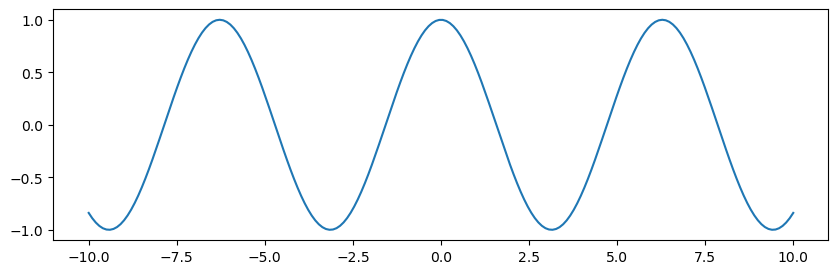

```python
#Import libraries
import torch
import torch.nn as nn
import matplotlib.pyplot as plt
import numpy

#Generate data of cosine
x=torch.linspace(-10,10,200)
y=torch.cos(x)                   # pytorch cosine function apply pointwise on a vector
plt.figure(figsize=(10,3))
plt.plot(x,y)
```

Next, we create a neural network with 3 layers. The input starts with 1 dimension, passes through a 40-dimensional space, then a 15-dimensional space, and finally maps to a 1-dimensional output (a real number).

```python
# Define a model
class NeuralNetwork(nn.Module):
    def __init__(self):
        super(NeuralNetwork,self).__init__()
        self.A1=nn.Linear(1,40)
        self.A2=nn.Linear(40,15)
        self.A3=nn.Linear(15,1)
    def forward(self,x):
        y=torch.tanh(self.A1(x))
        y=torch.tanh(self.A2(y))
        y=self.A3(y)
        return y
net=NeuralNetwork()
```

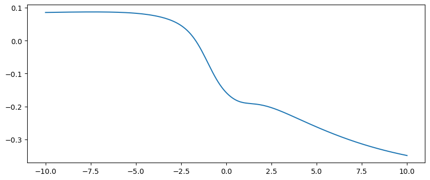

```python
# ploting the network before training
z=torch.zeros(len(x))
with torch.no_grad():
    for i in range(len(x)):
        z[i]=net(x[i:i+1])
plt.figure(figsize=(10,4))
plt.plot(x,z)
```

```python
#Define loss function
def loss_fn(a,b):
    return (a-b)**2
#choose learning rate
lr=0.01
```

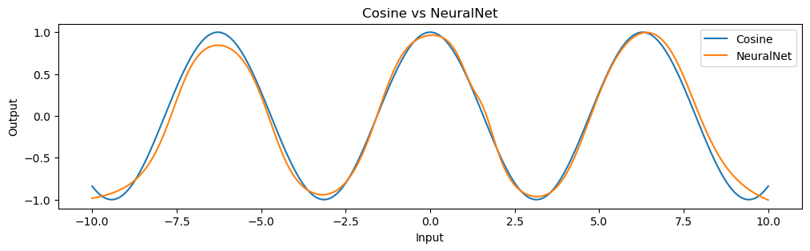

```python
# Start gradient decent step
for _ in range(40000):
    idx = torch.randint(0, len(x), (1,)).item()      # select a random index between 0 and size of x
    input=x[idx:idx+1]                               # get the point x corresponding to the index selected above
    output=y[idx]                                    # get the value of cosine
    predicted_out=net(input)                         # value computed by the neural network
    loss=loss_fn(predicted_out,output)               # compute the error
    net.zero_grad()                                  # make the gradient associate to parameter in net to be zero
    loss.backward()                                  # compute the gradient for any parameter used when computing loss
    with torch.no_grad():                            # stop tracking gradient
        for param in net.parameters():
            param.data -= lr * param.grad

# Now evaluat how the model changed after training
with torch.no_grad():
    predicted_by_net=net(x.view(-1,1))
plt.figure(figsize=(12,3))
plt.plot(x,y,label='Cosine')
plt.plot(x,predicted_by_net,label='NeuralNet')
plt.xlabel('Input')
plt.ylabel('Output')
plt.title('Cosine vs NeuralNet')
plt.legend()
```

Note that our batch size is 1. That's why I wanted the network to do gradient decent 40000 steps.

One might think that the network **"learn"** the cosine function. I think this is not the case, I think what the network does is it imitate the data it see and that's all to it. Let's plot the neural network prediction in a domain larger than what it've seen.

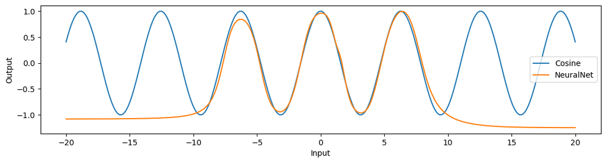

```python
x_l=torch.linspace(-20,20,1000) # create a larger domain
y_cos=torch.cos(x_l)
with torch.no_grad():
    y_net=net(x_l.view(-1,1))
plt.figure(figsize=(13,3))
plt.plot(x_l,y_cos,label='Cosine')
plt.plot(x_l,y_net,label='NeuralNet')
plt.xlabel('Input')
plt.ylabel('Output')
plt.legend()
```

An esay argument to see that a neural network defined above can never approximate the $\cos(x)$ on $\mathbb{R}$ regardless how big it is is that a neural network has only finitely many critical points while the cosine function has infinitly many critical points.

Now, let's me explain about the `zero_grad` issue. In PyTorch, when we create an tensor W, it could come as a pair (W,grad). And this is always true for parameter in neural network objects. For example, in the neural network we defined above, there are serveral parameters. If we do `net.A1`, this will give us a linear map `nn.Linear(1,40)`, which is an obect on its own. Now when we do `net.A1.weight`, we get the weight of `A1`, and associate to this weight is grad. This mean we have a pair (W,grad). The code `loss.backward()`, compute the the derivative of the loss function, and it updates gradient of any parameters that involve in computing the loss function, therefore W will get its gradient updated. In the begining, before the gradient is updated at all, grad=0, and `loss.backward()` update the gradient by accumulation, i.e., 0+grad. Note that this doesn't change the weight W itself. To change W, we must do gradient decent. After the gradient decent, the pair (W,grad) become (W_new,grad). Next if we do `loss.backward()` again, we would get a part (W_new,grad+grad(W_new)), so to avoid this problem, we need to make the pair (W_new,grad) to (W_new,0) first before we we do `loss.backward()`, and we can do this by `net.zero_grad()`, which set gradients of all parameter to be zero.

# 4. Loss Functions for Classification Task: Cross-Entropy

**Setup**: We have a set $D=\bigcup_{i=1}^ND_i$ as disjoint union of subsets $D_i$ . The function $F:D\to \mathbb{R}^N$ defined by $F(x)=e_i$ if $x\in D_i$, where $e_1,e_2,...,e_N$ are the standard unit vectors, allow us to classify point in $D$ based on which subset $D_i$ they are in. For each $x$, the vector value $F(x)$ can be thought as a probability distribution on $\{D_1,D_2,...,D_N\}$. To use neural network to do clasification task means to find a neural network $NN:D\to \mathbb{R}^N$ that approximate $F$ on $D$. The output $NN(x)\in \mathbb{R}^N$ should be thought of as a probability distribution.

Now need a way to compare two probability distributions. This will allow us to compare how well a neural network does a classification job.

**Definition**

Let's $P,Q:X\to [0,1]$ be a probability distribution over $X$. The cross entropy $H(P,Q)$ is defined as

\[ H(P, Q) = -\sum_{x \in X} P(x) \log(Q(x)) \]

It would be cool if the cross entropy is a metric. However, it is not, one obvious thing is that it is not symmetric, ie $H(P,Q)\neq H(P,Q)$. What make the cross entropy a good candidate as a measure how close $Q$ is to $P$ is the following ineqaulity $ H(P,Q)\geq H(P,P) $ This means that the smaller we can make the cross entropy, the better we make $Q$ close to $P$.

**Proof** Note that $$ H(P, Q) = -\sum_{x \in X} P(x) \log Q(x) $$ can be rewritten as $$ H(P, Q) = -\sum_{x \in X} \left( P(x) \log \frac{Q(x)}{P(x)} + P(x) \log P(x) \right) $$ which simplifies to $$ H(P, Q) = H(P, P) - \sum_{x \in X} P(x) \log \frac{Q(x)}{P(x)} $$ Now we need to prove that $D_{KL}(P \| Q) = -\sum_{x \in X} P(x) \log \frac{P(x)}{Q(x)} \geq 0$. Note that $D_{KL}(P \| Q)$ is called the Kullback-Leibler (KL) divergence. It is $0$ if and only if $P = Q$.

Now, $\log: \mathbb{R} \to \mathbb{R}$ is a concave function, therefore it satisfies the Jensen's inequality: $$ \sum_{i=1}^n \alpha_i \log(x_i) \leq \log\left( \sum_{i=1}^n \alpha_i x_i \right) $$ whenever $x_i \in [0, \infty]$ and $\alpha_i \in [0, 1]$ satisfies $\sum_{i=1}^n \alpha_i = 1$.

Applying this to the case where $\alpha_i = P(x_i)$ and $x_i = \frac{Q(x_i)}{P(x_i)}$, we get: $$ -D_{KL}(P \| Q) \leq \log\left( \sum_{x \in X} P(x) \frac{Q(x)}{P(x)} \right) = \log(1) = 0 $$ Thus, $D_{KL}(P \| Q) \geq 0$.

Back to using neural networks $NN$ to approximate probability distributions. We know that the output of the neural network is a vector $NN(x)=(s_1,s_2,...,s_N)$ in $\mathbb{R}^N$. This is not any probability distribution. To deal with this problem, we pass the result of the neural network into softmax function defined as:

**Definition** The function $\text{SoftMax} : \mathbb{R}^n \to I^n$ is defined by $$ \text{SoftMax}(x_1, \ldots, x_n) = (p_1, \ldots, p_n) = \left( \frac{e^{x_1}}{\sum_{i=1}^n e^{x_i}}, \ldots, \frac{e^{x_n}}{\sum_{i=1}^n e^{x_i}} \right) $$

# 5. Recurrent Nueral Network

Imagine we have a collection of news articles $\mathcal{C}=\{A_1,A_2,...,A_K\}$ and we want to classify them into $L$**={sport, politics, health}**. Each news article is a string of words. To process these articles, we need a way to represent each words numerically so that we can use mathematical techniques to do the classification task.

Assume $A_i=v_1...v_L$ where $v_{k}$ are words used to write $A_i$ and $L$ is the length of $A_i$. Let $\mathcal{W}=\{w_1,w_2,...,w_N\}$ be the set of vocabulary used to compose $\{A_1,...,A_K\}$, ordered in some manner. In the palance of natural language processing, $\mathcal{C}$ is refereed to as a corpus and $\mathcal{W}$ is the dictionary.

The goal is to represent $w_i$ numerically, one naive way to do this is to use number 1 to represent $w_1$, 2 to represent $w_2$, and so on. But the natural number has ordered structure, while we can't quite see that with words. So instead we should use vectors to represent words. More precisely, we want to find an embedding $E:\mathcal{W}\to \mathbb{R}^d$ for some $d$. One way to do this is to take $d=|\mathcal{W}|=N$ and send $w_i$ to the standard unit vector $e_i\in \mathbb{R}^N$, this is known as the one hot encoding. However, there are several issue with this method. First, the embedding dimension is large, for example there are around 600000 words in English. Second, $\mathbb{R}^N$ is a metric space, we would hope that that words $w_i$ and $w_j$ that are similar in meaning should be encoded closer compare to those that are not, but every pair of different words has distance $\sqrt{2}$ in the one-hot-encoding.

Continuous word embedding deal with the issues mentioned about the one one encoding. There is $d\ll |\mathcal{W}|$ and a map $E:\mathcal{W} \to \mathbb{R}^d$ that allow one to encoder each word as a vector where word with similar meaning stay close to one another. This is not a mathematical statement but rather an observed fact. We recommend the paper [A Neural Probabilistic Language Model](https://www.jmlr.org/papers/volume3/bengio03a/bengio03a.pdf) by Bengio et al for detail.

The classification problem mention in the beginning now can be seen as classification of sequences of various length where each terms of the sequences are in $\mathbb{R}^d$. A more general set up is having finite sequence $x_1,x_2,...,x_L$ in $\mathbb{R}^d$, find a map $f$ to the output space $Y$, which can be continuous or discreet. This is an example of time series analysis. To deal with time series, we introduce recurrent neural network.

## 5.1 Recurrent Neural Network (RNN)

The text $A_1=x_1,x_2,...,x_{L_{A_1}}$, where $x_i\in \mathbb{R}^d$. Any model that can classify this text should look at the whole text to do so. Let's try formulate this question of classifying text mathematically. Basically, we want a function $f$ that take input as finite sequence in $\mathbb{R}^d$ to $\mathbb{R}^3$, such that if the sequence coming from sport article, healths, and politics, $f$ would map it to $e_1$,$e_2$ and $e_3$, respectively. We can not find such a function, what we can do is to approximate it.

One way to we can do is to train a several layers neural network that take the concatenation of $x_i$, that is long vectors. However, here we run to the same problem of large dimensional space. The recurrent neural network was proposed to process sequence of any length and at the same time require relatively small number of parameters.

A recurrent neural network (RNN) processing the sequence $x_1,x_2,...,x_T$ is defined as follow $$ \begin{cases} h_t=f(x_t,h_{t-1}) \\ y_t=g(h_t) \end{cases} $$ for all $1\leq t\leq T$, with $h_t\in \mathbb{R}^H$ for some $H$ and $h_0=0$. We should think of $h_t$ as the memory of the system up to time $t$ and $y_t$ as the output. What happen is before anything happen, $h_0=0$, the system contain no information, and at time $t=1$, the system look at the first word $x_1$ and produce a memory. Next, it look at the second word $x_2$ and use previous memory $h_1$ to produce new memory $h_2$. The process repeat until the end of the sequence. In the classification task we mention earlier, we would want to use $y_T$ to make prediction of the class the news article belong to. $h_T$ obtained by the system after it looks at all words that make up of $A_1$.

We think of $y_t$ as the output of the network. And $h_t$ are known as hidden vector and $H$ is called the hidden dimension.

To truely get the name neural network, $f$ and $g$ should be composition of affine maps and non-linear activation functions. One choice is the following $$ \begin{cases} f(x,h)=\sigma(W_xx+W_hh+b_h)\\ g(h)=W_yh+b_y \end{cases} $$ Now we present a version of the universal approximation theorem of the RNN.

**Theorem** Let $F_1(x_1),F_2(x_1,x_2),...,F_T(x_1,..,x_T)$ be continuous functions with $x_i\in A\subset \mathbb{R}^d$ and their output are in $\mathbb{R}^m$. If $A$ is compact, then for any $\varepsilon>0$, there exist appropriate weight $W_x,W_h,W_y,b_h,b_y$ such that $$ \sup_{1\leq t\leq T}\sup_{x_i\in A}|F_t(x_1,..,x_t)-y_t|\leq \varepsilon $$ where $y_t$ is the output of the recurrent neural network with weights $W_x,W_h,W_y,b_h$ and $ b_y$.

We will not prove this theorem here.

## Other Variant of RNN

During training an RNN, we need to approximate gradient of the derivative of the model, which is a composition of functions. The longer the input sequence, the deeper the composition, and this leads to error in the approximation. Two phenomenons at least can happen, one is the gradient become close to zero, leading to slow training, and the other is the gradient is too large leading to unstable learning. To address these issue, various varience of RNN has been introduced. We will introduce two of them here and from now on **we will call all of them as RNN, and all that we care for is the hidden state $h_t$**.

## 5.2 Long Short Term Memory: LSTM

An LSTM consists of several key components called gates or cells. These components include the forget gate, input gate, cell state update, and output gate.

Given the input at time step $ t $, $ \mathbf{x}_t $, the previous hidden state $ \mathbf{h}_{t-1} $, and the previous cell state $ \mathbf{C}_{t-1} $, the LSTM cell performs the following operations:

1. Forget Gate: $$ \mathbf{f}_t = \sigma(\mathbf{W}_f \mathbf{x}_t + \mathbf{U}_f \mathbf{h}_{t-1} + \mathbf{b}_f) $$ where $ \sigma $ is the sigmoid function.
2. Input Gate: $$ \mathbf{i}_t = \sigma(\mathbf{W}_i \mathbf{x}_t + \mathbf{U}_i \mathbf{h}_{t-1} + \mathbf{b}_i) $$
3. Cell State Update: $$ \mathbf{\tilde{C}}_t = \tanh(\mathbf{W}_C \mathbf{x}_t + \mathbf{U}_C \mathbf{h}_{t-1} + \mathbf{b}_C) $$ The new cell state is computed as: $$ \mathbf{C}_t = \mathbf{f}_t \odot \mathbf{C}_{t-1} + \mathbf{i}_t \odot \mathbf{\tilde{C}}_t $$ where $ \odot $ denotes element-wise multiplication.
4. Output Gate: $$ \mathbf{o}_t = \sigma(\mathbf{W}_o \mathbf{x}_t + \mathbf{U}_o \mathbf{h}_{t-1} + \mathbf{b}_o) $$
5. Hidden State Update: $$ \mathbf{h}_t = \mathbf{o}_t \odot \tanh(\mathbf{C}_t) $$

In summary, the equations for the LSTM cell are:

\begin{align*} \mathbf{f}_t &= \sigma(\mathbf{W}_f \mathbf{x}_t + \mathbf{U}_f \mathbf{h}_{t-1} + \mathbf{b}_f) \\ \mathbf{i}_t &= \sigma(\mathbf{W}_i \mathbf{x}_t + \mathbf{U}_i \mathbf{h}_{t-1} + \mathbf{b}_i) \\ \mathbf{\tilde{C}}_t &= \tanh(\mathbf{W}_C \mathbf{x}_t + \mathbf{U}_C \mathbf{h}_{t-1} + \mathbf{b}_C) \\ \mathbf{C}_t &= \mathbf{f}_t \odot \mathbf{C}_{t-1} + \mathbf{i}_t \odot \mathbf{\tilde{C}}_t \\ \mathbf{o}_t &= \sigma(\mathbf{W}_o \mathbf{x}_t + \mathbf{U}_o \mathbf{h}_{t-1} + \mathbf{b}_o) \\ \mathbf{h}_t &= \mathbf{o}_t \odot \tanh(\mathbf{C}_t) \end{align*}

Here, $ \mathbf{W}_f, \mathbf{W}_i, \mathbf{W}_C, \mathbf{W}_o $ are the weight matrices for the respective gates, $ \mathbf{U}_f, \mathbf{U}_i, \mathbf{U}_C, \mathbf{U}_o $ are the weight matrices for the hidden state, and $ \mathbf{b}_f, \mathbf{b}_i, \mathbf{b}_C, \mathbf{b}_o $ are the bias vectors.

## 5.3 Gated Recurrent Unit

A GRU consists of two main gates that manage the update of the hidden state: the reset gate and the update gate.

Given the input at time step $ t $, $ \mathbf{x}_t $, and the previous hidden state $ \mathbf{h}_{t-1} $, the GRU cell performs the following operations:

1. Reset Gate: $$ \mathbf{r}_t = \sigma(\mathbf{W}_r \mathbf{x}_t + \mathbf{U}_r \mathbf{h}_{t-1} + \mathbf{b}_r) $$ where $ \sigma $ is the sigmoid function.
2. Update Gate: $$ \mathbf{z}_t = \sigma(\mathbf{W}_z \mathbf{x}_t + \mathbf{U}_z \mathbf{h}_{t-1} + \mathbf{b}_z) $$
3. Candidate Hidden State: $$ \mathbf{\tilde{h}}_t = \tanh(\mathbf{W}_h \mathbf{x}_t + \mathbf{U}_h (\mathbf{r}_t \odot \mathbf{h}_{t-1}) + \mathbf{b}_h) $$ where $ \odot $ denotes element-wise multiplication.
4. Hidden State Update: The new hidden state is a linear interpolation between the previous hidden state and the candidate hidden state: $$ \mathbf{h}_t = (1 - \mathbf{z}_t) \odot \mathbf{h}_{t-1} + \mathbf{z}_t \odot \mathbf{\tilde{h}}_t $$

In summary, the equations for the GRU cell are:

\begin{align*} \mathbf{r}_t &= \sigma(\mathbf{W}_r \mathbf{x}_t + \mathbf{U}_r \mathbf{h}_{t-1} + \mathbf{b}_r) \\ \mathbf{z}_t &= \sigma(\mathbf{W}_z \mathbf{x}_t + \mathbf{U}_z \mathbf{h}_{t-1} + \mathbf{b}_z) \\ \mathbf{\tilde{h}}_t &= \tanh(\mathbf{W}_h \mathbf{x}_t + \mathbf{U}_h (\mathbf{r}_t \odot \mathbf{h}_{t-1}) + \mathbf{b}_h) \\ \mathbf{h}_t &= (1 - \mathbf{z}_t) \odot \mathbf{h}_{t-1} + \mathbf{z}_t \odot \mathbf{\tilde{h}}_t \end{align*}

Here, $ \mathbf{W}_r, \mathbf{W}_z, \mathbf{W}_h $ are the weight matrices for the respective gates, $ \mathbf{U}_r, \mathbf{U}_z, \mathbf{U}_h $ are the weight matrices for the hidden state, and $ \mathbf{b}_r, \mathbf{b}_z, \mathbf{b}_h $ are the bias vectors.

## 6. RNN Based Language Model

A language model is a function that takes sequence of words as input and output a new word. This allows one to get another new word using the word just genereated and the previous word and one can keep produce as many word as one wants this way. This is called auto-regressive model.

In this section, we would build a character level language model based on RNN. What we mean is we would use one of the RNN model to process a squence and use the hidden state to produce the resulting prediction.

The strategy is as follow. First we one hot encode each character, ie if the list of characers are $\{c_1,c_2,..,c_K\}$, then $\text{one-hot}(c_j)=e_j\in \mathbb{R}^K$. Next we will project this embedding into another space $\mathbb{R}^d$ via a map $E:\mathbb{R}^K\to \mathbb{R}^d$, this process is called continuous embedding, and it can be done by multiplying $e_j$ by a matrix $E$, which is a learnable parameters. This whole process allow us to turn a sequnece of character to a sequence of vectors in $\mathbb{R}^d$, and from here we can use an RNN to approximate $$ P(w_{n+1}|w_1,...,w_n). $$ This conditional probablity is a map $P:(w_1,..,w_n)\to \mathbb{R}^K$.

An RNN would be able to take arbitarly lenght senquence and make prediction. If an RNN can learn to predict the next word based on a dependency of a long sequence, then it would be best. But we can't take too long a sequence, since the longer the sequnce is, the more difficult for us to approximate the gradient, hence no effective learning.

The maximum lenght of sequence we choose to process is called block size. Now let's say we have block_size=32, this mean we want to use 32 character to predict the next characters. Let $\mathcal{T}$ be the text corpus we used for training. This mean during training, we take a chunk of 33 character piece of $\mathcal{T}$, $w_1.....w_{32}w_{33}$, use $w_1w_2...w_{32}$ as input and $w_{33}$ as output. The RNN goes through the embedding $x_1,x_2,...,x_{32}$ of $w_1w_2...w_{32}$ to produce $h_1,h_2,...,h_{32}$, and we use $h_{32}$ to predict $w_{33}$ by map $g:\mathbb{R}^H\to \mathbb{R}^K$ defined by $g(h)=\text{SoftMax}(W_yh+b_y)$.

Now if we want our model to take any sequence of length less than 32 to predict the next word, the data should be something like this $x_1$ predict $w_2$, $x_1x_2$ predict $w_3$ and so on. And good news is we don't need to do more work for this, to compute $h_{32}$, we already compute $h_1,h_2,...$, so what should do is apply $g$ on these hidden vector. Now the input and output look like $w_1w_2....w_{32}$ and $w_2.....w_{33}$, respectively, and the loss function is $$ \dfrac{1}{32} \sum_{k=2}^{32} H(e_{w_k},g(h_{k-1})) $$ Another thing to note is that we probably want to train a batch of data at the same time, this mean we should stable text at several places at time, and each place we would take 33 characters.

Next we want to talk about continuous embedding. Earlier, we mention that we should do one hot encoding and then map it to a low dimensional space. This is unnessary in PyTorch. Let's me explain this. Say we have the text T=hello, then directionary for this text is {e,h,l,o}, we can label e as 1, h as 2, l as 3 and o as 4, and the text is translated to 21334. Note that the vocabulary size is 4. The object `nn.Embedding(4,3)` take input of shape (batch_size,sequence_lenght) with each entry as "interger" and produce output of shape (batch_size, sequence_length,3=embedding_dimension). So basically, as soon as we encode a text as sequence of integers, we can feed it to `nn.Embedding(4,3)` to get continous embedding. Note that 4 here is the size of the vocabylary.

```python
# importing necessary package
import torch
import torch.nn as nn                                    #  this one is for neural network object
import torch.optim as optim                              #  this one is for optimizing algorithsm
import torch.nn.functional as F                          #  this one is used for functions like sigmoid and relu etc
import numpy

#hyper parameter
seq_length=30
batch_size=32
device='gpu' if torch.cuda.is_available() else 'cpu'     #  this tell the computer where the computation work
n_embd=128                                                #  this is for embedding dimension
hidden_size=128
num_layer=2                                              #  one can stack RNN on top of each other to create deep RNN
learning_rate=0.001
max_iters=10000                                          #  this is for the numder of gradient decent we take
eval_interval=1000                                       #  the frequency which we evaluate the perfromance of the model
eval_iters=1000
```

The following text is a news article about Grothendieck by [He was in mystic delirium’: was this hermit mathematician a forgotten genius whose ideas could transform AI – or a lonely madman?](https://www.theguardian.com/science/article/2024/aug/31/alexander-grothendieck-huawei-ai-artificial-intelligence) by The Guardian.

```python
text="One day in September 2014, in a hamlet in the French Pyrenean foothills, Jean-Claude, a landscape gardener in his late 50s, was surprised to see his neighbour at the gate. He had not spoken to the 86-year-old in nearly 15 years after a dispute over a climbing rose that Jean-Claude had wanted to prune. The old man lived in total seclusion, tending to his garden in the djellaba he always wore, writing by night, heeding no one. Now, the long-bearded seeker looked troubled. Then, in 1970, in what he later called his great turning point, Grothendieck quit. Resigning from Frances elite Institut des Hautes Etudes Scientifiques IHES in protest at funding it received from the ministry of defence put an end to his high-level mathematics career. He occupied a few minor teaching posts until 1991, when he left his home underneath Provences Mont Ventoux and disappeared. No one friends, family, colleagues, the intimates who knew him as Shurik his childhood nickname, the Russian diminutive for Alexander knew where he was. Would you do me a favour he asked Jean-Claude. If I can. Could you buy me a revolver. Jean-Claude refused. Then, after watching the hermit who was deaf and nearly blind totter erratically about his garden, he telephoned the mans children. Even they had not spoken to their father in close to 25 years. When they arrived in the village of Lasserre, the recluse repeated his request for a revolver so he could shoot himself. There was barely room to move in his dilapidated house. The corridors were lined with shelves heaving with flasks of mouldering liquids. Overgrown plants spilled out of pots everywhere. Thousands of pages of arcane scrawling were lined up in canvas boxes in his library. But his infirmity had put paid to his studies, and he no longer saw any purpose in life. On 13 November, he died exhausted and alone in hospital in the neighbouring town of St-Lizier. The hermits name was Alexander Grothendieck. Born in 1928, he arrived in France from Germany as a refugee in 1939, and went on to revolutionise postwar mathematics as Einstein had physics a generation earlier. Moving beyond distinct disciplines such as geometry, algebra and topology, he worked in pursuit of a deeper, universal language to unify them all. At the heart of his work was a new conception of space, liberating it from the Euclidean tyranny of fixed points and bringing it into the 20th-century universe of relativity and probability. The flood of concepts and tools he introduced in the 1950s and 1960s awed his peers. Grothendiecks capacity for abstract thought is legendary. He rarely made use of specific equations to grasp at mathematical truths, instead intuiting the broader conceptual structure around them to make them surrender their solutions all at once. He compared the two approaches to using a hammer to crack a walnut versus soaking it patiently in water until it opens naturally. He was above all a thinker and a writer, who decided to apply his genius mostly to mathematics says Olivia Caramello, a 39-year-old Italian mathematician who is the leading proponent of his work today. His approach to mathematics was that of a philosopher, in the sense that the way in which one would prove results was more important to him than the results themselves. In Lasserre, he lived in near-complete solitude, with no television, radio, phone or internet. A handful of acolytes trekked up to the village once his whereabouts filtered out; he politely refused to receive most of them. When he did exchange words, he sometimes mentioned his true friends the plants. Wood, he believed, was conscious. He told Michel Camilleri, a local bookbinder who helped compile his writings, that his kitchen table knows more about you, your past, your present and your future than you will ever know. But these wild preoccupations took him to dark places he told one visitor that there were entities inside his house that might harm him. Grothendiecks genius defied his attempts at erasing his own renown. He lurks in the background of one of Cormac McCarthys final novels, Stella Maris, as an eminence grise who leads on its psychically disturbed mathematician protagonist. The long-awaited publication in 2022 of Grothendiecks exhaustive memoir, Harvests and Sowings, renewed interest in his work. And there is growing academic and corporate attention to how Grothendieckian concepts could be practically applied for technological ends. Chinese telecoms giant Huawei believes his esoteric concept of the topos could be key to building the next generation of AI, and has hired Fields medal-winner Laurent Lafforgue to explore this subject. But Grothendiecks motivations were not worldly ones, as his former colleague Pierre Cartier understood. Even in his mathematical milieu, he was not quite a member of the family writes Cartier. He pursued a kind of monologue, or rather a dialogue with mathematics and God, which to him were one and the same. Beyond his mathematics was the unknown. Were his final writings, an avalanche of 70000 pages in an often near-illegible hand, the aimless scribblings of a madman Or had the anchorite of Lasserre made one last thrust into the secret architecture of the universe And what would this outsider who had spurned the scientific establishment and modern society make of the idea of tech titans sizing up his intellectual property for exploitation In a famous passage from Harvests and Sowings, Grothendieck writes that most mathematicians work within a preconceived framework. They are like the inheritors of a large and beautiful house all ready-built, with its living rooms and kitchens and workshops, and its kitchen utensils and tools for all and sundry, with which there is indeed everything to cook and tinker. But he is part of a rarer breed the builders whose instinctive vocation and joy is to construct new houses. Now his son, Matthieu Grothendieck, is working out what to do with his fathers home. Lasserre lies on the top of a hill 22 miles 35km north of the Spanish border, in the remote Ariege departement, a haven for marginals, drifters and utopians. I first walk up there one piercingly cold January morning in 2023, mists cloaking forests of oak and beech, red kites surveying the fields in between. Grothendiecks home one of Laserrerres few three-storey houses, built by affluent dressmakers is at the villages southern extremity. Hanging above the road beyond are the snow-covered Pyrenees a promise of a higher reality. Matthieu answers the door wearing a dressing gown, with the sheepish air of a man emerging from hibernation. The 57-year-old has deeply creased features and a strong prow of a nose. Inheriting the house where his father experienced such mental ordeals weighs on him. This place has a history that is bigger than me he says, his voice softened by smoking. And as I have not got the means to knock it into shape, I feel bad about that. I feel as if I am still living in my fathers house. A former ceramicist, he is now a part-time musician. In the kitchen, a long framed scroll of Chinese script stands on a sideboard, next to one photograph of a Buddha sculpture and two of his mother, Mireille Dufour, whom Grothendieck left in 1972. Matthieu is her youngest child; he has a sister, Johanna, and brother, Alexandre. Grothendieck also had two other sons, Serge and John, with two other women. Above Matthieus bed is a garish portrait of his paternal grandfather, Alexander Schapiro, a Ukrainian Jewish anarchist who lost an arm escaping a tsarist prison, and later fought in the Spanish civil war. Schapiro and his partner, the German writer Johanna Grothendieck, left the five-year-old Grothendieck in foster care in Hamburg when they fled Nazi Germany in 1933 to fight for the socialist cause in Europe. He was reunited with his mother in 1939, and lived the remainder of the war in a French internment camp or in hiding. But his Jewish father, interned separately, was sent to Auschwitz and murdered on arrival in 1942. It was this legacy of abandonment, poverty and violence that drove the mathematician and finally overwhelmed him, Matthieu suggests. Artists and geniuses are making up for flaws and traumas. The wound that made Shurik a genius caught up with him at the end of his life. Matthieu leads me into the huge, broken-down barn behind the house. Heaped on the bare-earth floor is a mound of glass flasks encased in wicker baskets inside them are what remains of the mathematicians plant infusions, requiring hundreds of litres of alcohol. Far removed from conventional mathematics, Grothendiecks final studies were fixated on the problem of why evil exists in the world. His last recorded writing was a notebook logging the names of the deportees in his fathers convoy in August 1942. Matthieu believes his fathers plant distillations were linked with this attempt to explain the workings of evil a form of alchemy through which he was attempting to isolate different species properties of resilience to adversity and aggression. It is hard to understand says Matthieu. All I know is that they were not for drinking. Later, Matthieu agrees to let me look at his fathers Lasserre writings a cache of esoterica scanned onto hard disk by his daughter. At the start of 2023, the family were still negotiating their entry into the French national library. The writings have now been accepted and at some point will be publicly available for research. Serious scholarship is needed to decide their worth on mathematical, philosophical, and literary levels. I am definitely not qualified on the first count. I open a first page at random. The writing is spidery; there are occasional multicoloured topological diagrams, namechecks of past thinkers, often physicists Maxwell, Planck, Einstein and recurrent references to Satan and this cursed world. His children are struggling to fathom this prodigious output too. It is mystic but also down to earth. He talks about life with a form of moralism. It is completely out of fashion says Matthieu. But in my opinion there are pearls in there. He was the king of formulating things. After a couple of hours reading, head spinning, I feel the abyss staring into me. So imagine what it was like for Grothendieck. According to Matthieu, a friend once asked his father what his greatest desire was. The mathematician replied that this infernal circle of thought finally ceases. The colossal folds of Mont Ventouxs southern flank are mottled with April cloud shadow as cyclists skirt the mountain. In the Vaucluse departement of Provence, this is the terrain where Alexander Grothendieck took his first steps into mysticism. Now, another of his sons, Alexandre, lives in the area. I wander up a bumpy track to see the 62-year-old ambling out of oak woods, smiling, to meet me. Wearing a moth-eaten jumper, dark slacks, and slippers, Alexandre is slighter than his brother, with wind-chafed cheeks. He leads me into the giant hangar where he lives. It is piled with amps and instruments; at the back is a workshop where he makes kalimbas, a kind of African thumb piano. In 1980, his father moved a few kilometres to the west, to a house outside the village of Mormoiron. In the subsequent years, Grothendiecks thoughts turned inwards towards bewildering spiritual vistas. Even with all his wisdom and the depth of his insight, there was always a sense of excessiveness about my father says Alexandre. He always had to put himself in danger. He searched for it. Grothendieck had abandoned the commune he had been part of since 1973 in a village north of Montpellier, where he still taught at the university. From 1970 onwards, he had been one of Frances first radical ecologists and became increasingly preoccupied with meditation. In 1979, he spent a year dwelling intensely on his parents letters, a reflection that stripped away any lingering romanticism about them. The myth of their great love fell flat for Shurik it was a pure illusion says Johanna Grothendieck, who bears her grandmother's name. And he was able to decrypt all the traumatic elements of his childhood. He realised he had been quite simply abandoned by his own mother. This preoccupation with the past intensified into the mid-1980s, as Grothendieck worked on the manuscript for Harvests and Sowings. A reflection on his mathematical career, it was filled with stunning aphoristic insights, like the house metaphor. But, choked with David Foster Wallace-like footnotes, it was relentless and overwhelming too and steeped in a sense of betrayal by his former colleagues. In the wake of his revelations about his parents, this feeling became a kind of governing principle. It was a systematic thing with our papa to put someone on a pedestal, in order to see their flaws. Then bam they went down in flames says Alexandre. Although he still produced some mathematical work during this period, Grothendieck delved further into mysticism. He looked to his dreams as a conduit to the divine. He believed they were not products of his own psyche, but messages sent to him by an entity he called the Dreamer. This being was synonymous with God; as he conceived it, a kind of cosmic mother. Like a maternal breast, the grand dream offers us a thick and savorous milk, good to nourish and invigorate the soul he later wrote in The Key of Dreams, a treatise on the subject. Pierre Deligne, the brilliant pupil he accused in Harvests and Sowings of betraying him, felt his old master had lost his way. This was not the Grothendieck I admired he says, on the phone from Princetons Institute for Advanced Study. By summer 1989, the prophetic dreams had intensified into daily audiences, absorbing almost all of my time and energy with an angel Grothendieck called either Flora or Lucifera, depending on whether she manifested as benevolent or tormenting. She tutored him in a new cosmology, central to which was the question of suffering and evil in God's greater scheme. He believed, for example, that the speed of light being close to, but not precisely, 300000km a second, was evidence of Satans interference. He was in a form of mystic delirium says another former pupil, Jean Malgoire, now a professor at Montpellier University. Which is also a form of mental illness. It would have been good if he could have been seen by a psychiatrist at that point. In real life, he had become forbidding and remote. Matthieu spent two months in Mormoiron working on the house. During that time, his father invited him in only once. His son blew his top. He had lost interest in others. I could no longer feel any authentic or sincere empathy. But Grothendieck was still interested in people's souls. On 26 January 1990, he sent 250 of his acquaintances including his children a messianic, seven-page typed epistle, entitled Letter of the Good News. He announced a date 14 October 1996 for the Day of Liberation when evil on Earth would cease, and said they had been chosen to help usher in the new era. It was a kind of remake of the most limited aspects of Christianity says Johanna."
```

```python
vocabs=sorted(set(text))
char_to_idx={char:idx for idx,char in enumerate(vocabs)}  # translate from character to index based on vocabs
idx_to_char={idx:char for idx,char in enumerate(vocabs)}  # translate from  index
encode= lambda s: [char_to_idx[char] for char in s]       # this is a function that convert a sequence of chars to seq of integers
decode= lambda l: ''.join(idx_to_char[idx] for idx in l)  # convert a sequnece of integers to sequence of chars
data=torch.tensor(encode(text),dtype=torch.long)          # used function encode to turn the whole text to a sequence of integer
n=int(0.8*len(text))                                      # we make a cut to get part of the data for training and for testing
train_data=data[:n]                                       # this is part of the data used for training
val_data=data[n:]                                         # this is part of the data used for testing, unseen by during training
vocab_size=len(vocabs)

# We create a function that catch a batch of data for stochastic gradient decent
def get_batch(split):
    data=train_data if split == 'train' else val_data      # there are two type of data, from train_data and from val_data
    idx=torch.randint(len(data)-seq_length, (batch_size,)) # this produces an array of size (batch_size) of random integers
    x=torch.stack([data[i:i+seq_length] for i in idx])     # get a batch of input data
    y=torch.stack([data[i+1:i+seq_length+1] for i in idx]) # get a batch of output data
    x,y=x.to(device),y.to(device)                          # move x and y to device
    return x,y
```

```python
@torch.no_grad()
def estimate_loss():
    out = {}
    model.eval()  # Set model to evaluation mode
    for split in ['train', 'val']:                      # there are 2 type of loss, one for train_data and one for val_data
        losses = torch.zeros(eval_iters)                # create tensor to hold losses for each sample
        for k in range(eval_iters):                     # we compute loss for eval_iters batches of data
            X, Y = get_batch(split)                     # get batch of data
            logits, loss = model(X, Y)                  # forward pass
            losses[k] = loss.item()                     # store the loss for each batch of data
        out[split] = losses.mean().item()               # compute the mean loss after the loop
    model.train()                                       # set model back to training mode
    return out
```

```python
class RNNLanguageModel(nn.Module):
    def __init__(self):                                    # attribuate part of the data
        super().__init__()                                 # initialize the model
        self.embd_table = nn.Embedding(vocab_size, n_embd) # continous embedding
        self.lstm = nn.LSTM(n_embd, hidden_size, num_layers=num_layer, batch_first=True) # we use LSTM instead of vanilla RNN
        self.proj = nn.Linear(hidden_size, vocab_size)     # this is the function g:R^h to R^vocab_size before the softmax

    def forward(self, idx, targets=None):                  # during inference, we don't need target. The model take idx as input
        B, T = idx.shape                                   # get_batch produce idx of the shape (batch_size, sequence_length)
        tok_emb = self.embd_table(idx)                     # turn index to continuous embedding
        output, _ = self.lstm(tok_emb)                     # the LSTM processes sequence of vectors input, out=seqence of h_t
        logits = self.proj(output)                         # project h_t to prepare for softmax

        if targets is None:  # Corrected variable name     # if this is during inference, ie no target
            loss = None
        else:                                              # if during training, we use to logits to compute cross-entropy
            B, T, C = logits.shape
            logits = logits.view(B * T, C)                 # there are B*T prediction that logits make
            targets = targets.view(B * T)                  # there are B*T ground truth
            loss = F.cross_entropy(logits, targets)

        return logits,loss

    def generate(self, idx, generate_length, seq_length):      # this are the input for generating an output
        hidden = None                                          # ensure that first hidden state h_0,c_0=0
        for _ in range(generate_length):
            idx_cond = idx[:, -seq_length:]                    # use at most seq_length argument as input for LSTM
            tok_emb = self.embd_table(idx_cond)
            output, hidden = self.lstm(tok_emb, hidden)
            logits = self.proj(output[:, -1, :])               # select the last hidden state and project it to get logits
            probs = F.softmax(logits, dim=-1)                  # apply softmax on logits along the last dimension
            idx_next = torch.multinomial(probs, num_samples=1) # select next index according to probability distribution prob
            idx = torch.cat((idx, idx_next), dim=1)            # add the prediction to the list of ouput
        generated_text=decode(idx[0].tolist())
        return generated_text
model=RNNLanguageModel()                                       # this initialize a model
total_params = sum(p.numel() for p in model.parameters() if p.requires_grad)
print(f"Total trainable parameters: {total_params}")
print(f"The text length is {len(text)}")
print(f"The ratio of parameters to text is {total_params/len(text):.4f}")
```

```
Total trainable parameters: 280640
The text length is 15069
The ratio of parameters to text is 18.6237
```

```python
# create a PyTorch optimizer
optimizer = torch.optim.AdamW(model.parameters(), lr=learning_rate)
for iter in range(max_iters):
    # every once in a while evaluate the loss on train and val sets
    if iter % eval_interval == 0 or iter == max_iters - 1:
        losses = estimate_loss()
        print(f"step {iter}: train loss {losses['train']:.4f}, val loss {losses['val']:.4f}")
    # sample a batch of data
    xb, yb = get_batch('train')
    # evaluate the loss
    logits, loss = model(xb, yb)
    optimizer.zero_grad(set_to_none=True)
    loss.backward()
    optimizer.step()
```

```
step 0: train loss 4.1654, val loss 4.1654
step 1000: train loss 1.4833, val loss 2.0562
step 2000: train loss 0.8643, val loss 2.4494
step 3000: train loss 0.5319, val loss 2.8772
step 4000: train loss 0.3966, val loss 3.2577
step 5000: train loss 0.3432, val loss 3.5259
step 6000: train loss 0.3147, val loss 3.6953
step 7000: train loss 0.2999, val loss 3.8593
step 8000: train loss 0.2877, val loss 3.9589
step 9000: train loss 0.2799, val loss 4.0387
step 9999: train loss 0.2718, val loss 4.1391
```

```python
# The training loss become very small, the model literally memory the data
# generate from the model
context = torch.ones((1, 3), dtype=torch.long, device=device)
#print(decode(model.generate(context,500,seq_length)[0].tolist()))
print(model.generate(context,500,seq_length))
```

```
'''s. But inwered out; he politely refused to receive most of them. When he did exchange words, he sometimes mention the dooble making it polstebook logging the names of the topos could be key to building the next generation of AI, and has harm to move in his ligens and your future than you will eve…
```

## 6.1 The n-gram Language Model

We've seen that the RNN model earlier attempts to approximate $P(w_{L+1}|w_1,...,w_L)$. Another way to get this probability distribution is to actually count it, since this is a finite system. This is known as the **n-gram** model. Allow me to explain the 3-gram model and then you'll understand the n-gram model. Let's say we want to predict the next word based on 3 words before it that imitates a text $\mathcal{T}$, ie $\mathcal{T}$ is the training data. First, we can ask what the possible combination of 3 words are. If the text $\mathcal{T}$ is based on 1000 words, then there are $1000^3$ possible of 3 words sentences. Next for each of the combination $w_1w_2w_3$, we count its occurence in the text, and cound what are the word that come after it and in what frequency, from here we can compute the exact probability.

Our goal here is not to study the n-gram model itself, but to use it to help us understand better what the RNN and other lanaguage model does.

Now what are some of the problem encounter by the n-gram model? First, one main issue is that the n-gram model would give uniform distribution for any sequence of words that doesn't appear in the text. Consider creating an 2-gram model based on a text that the sequence **cat loves** doesn't exist, when we ask the model to predict what word come next after this sequnce, it will predict anyting can happen with eqaul probablity. We don't want something like that. The RNN model takes input as sequence of vectors, and it can process any sequence, so it doesn't face the problem that n-gram model has. One way one hope the RNN give good prediction is as follow: During embedding, as the model look through the text, it learns that the embedding of the word **like** and **love** are close, and it has seen the sequence **cat likes** in the text, this allow us to give a non-uniform distribution for the **$P(.|\text{cat loves})$** based on what it seen for **cat likes**. **One question one can ask is does the RNN do more than a modifcation of the n-gram model?** By modified RNN here we mean something like this: the model first regroup all possible 3 words sentences based on their similar meaning and then does the 3-gram model on that.

The hope here is that the embedding learned during the training of the RNN is a way that allows us to embed each word in $\mathbb{R}^d$, making words with similar meaning to be nearby.

# 7. Transformer Model

Transformer was first introduced by Vaswani et al., in 2017 in the widely cited paper **["Attention Is All You Need"](https://doi.org/10.48550/arXiv.1706.03762)**, where the authors tested it as a neural network-based machine translation model. One of the key ingredients in the transformer model is **self attention** mechanism. **Andrej Karpathy** thinks of attention mechanism as a way for words in a sentence to communicate with each other. The following presentation is how I like to think about the transformers.

## 7.1 Decoder only transformer

In the above RNN-based language model, the RNN takes a sequence of words $w_1w_2...w_N$ and then turns it to sequence of vectors $x_1x_2...x_N$ via continuous word embedding, and condenses it to get the sequence of hidden vectors $h_1,h_2,...h_N$, and we use $h_N$ to predict the next word. We can think of $h_i$ as containing richer and richer information about the sequence $x_1...x_N$ as $i$ increases.

The way RNN condenses the sequence $x_1x_2...x_N$ is highly non-linear and highly non-commutative, which makes it hard to approximate its partial derivatives, leading to ineffective learning. The transformer model is somewhat less non-commutative and look linear, and in practice it turns out to be a lot easier to train.

Now say we have a sequence $x_1,x_2,...x_N$, the vector $$ v=x_1+x_2+...+x_N $$ could contain the information of a sequence $x_1x_2..x_N$, but probably we shouldn't hope that this information is sufficent to make next word prediction. One way to upgrade this and still keep things "linear" is to do $$ v=a_1x_1+a_2x_2+....+a_Nx_N $$ where $a_1,a_2,...a_N$ are some real numbers. The appropriate choice of $a_1,...,a_N$ would give us a represention of the sentence $x_1...x_N$. The transformer model suggests somewhat different from this, it suggests we should upgrade the embedding of each word $x_i$ in the sentence to incooperate the context it is in. This context enrichment process takes embedding vector $x_i\in \mathbb{R}^d$ to context-aware vector $y_i=a_1^ix_1+a_2^ix_2+....+a_N^ix_N$ of the same dimension. The coefficient $a_j^i$ should depend on both $x_i$ and $x_j$. The idea is that $a_j^i$ tells us how much $x_j$ attends to $x_i$, therefore the name attention mechanism. Furthermore, instead of combining the vectors $x_j$ themselves, the model uses another linear transformed of $x_j$ call value vectors, denoted by $v_j$. Here is the summery of how the model work roughly.

1. Convert $x_j$ to $q_j$,$k_j$ and $v_j$, called query, key and value of $x_j$, respectively.
2. Compute the dot product $e_j^i=(q_i,k_j)$, called scores.
3. Turn the score vector $E^i=(e_1^i,...,e_N^j)$ into convex hall coefficents vector via softmax, i.e., $A^i=\text{SoftMax}(E^i)$, where $A^i$ is called attention.
4. Compute the convex combination $y_i=a_1^iv_1+...+a_N^iv_N$, where $A^i=(a_1,...,a_n)$.

Now we transform $x_1,x_2,...x_N$ to $y_1,y_2,...,y_N$. We want to think of $y_i$ as an enriched version of $x_i$, based on the context sequence $x_1...x_N$.

Let me explain what I think could be the motivation, people in ML community has several different way of thinking about this and here I present what I think what happen.

First, how do we convert $x_i$ to key, query and value vectors? This is done by multiplying $x_i$ by matrices $W_K,W_Q$, and $W_V$, respectively, and these matrices are learned during training. This allows us to give different represent of $x_i$ for different usages. Computing the dot product to get $e^i_j$ allow us to measure a sense of interaction/relation between $x_i$ and $x_j$ and this computation isn't the direct dot product of these two vectors but rather their other representations.

Onbiously, the computation of $y_i$ are highly non-linear since it involves using the SoftMax function. However, because we only use that as a linear coefficents, this makes $y$ like a "linear combination" of $x$. Next, we note that $y_i$ is independent of the order of $x_j$, this is rather different from the case with RNN.

The process we've seen so far is called self attention (actually almost). In this note, I refer to it as attention. Next we write down equation for attention mechanism that is more efficent, and add correction term. First we make a matrix $X=[x_1,x_2...,x_N]$, and the equation for key, query, value, score and attention is as follow

1. $ K = W_K X $, $ Q = W_Q X $, $ V = W_V X $
2. Score matrix $E=\left(\dfrac{K^T Q}{\sqrt{d}}\right)$.
3. Attention = $ \text{SoftMax}\left(\dfrac{K^T Q}{\sqrt{d}}\right) $
4. Attn($X$) = $\text{SoftMax}\left(\dfrac{K^T Q}{\sqrt{d}}\right)V = \text{Attention} \times V $

The division by $\sqrt{d}$, where $d$ is the dimension of the embedding, is to increase the variant of the attention, avoiding the issue of just averaging $v_i$, or just selecting one vector. As we discuss earlier, we tend to think of the computation of the attention is a linear process, so to introduce some non-linearity, we pass the attended vectors through a feed-forward neural network. $$ \text{FFN}(Y)=W_2\text{ReLu}(W_1Y+b_1)+b_2 $$ where $W_1\in \mathcal{L}(\mathbb{R}^d,\mathbb{R}^h)$ and $W_1\in \mathcal{L}(\mathbb{R}^h,\mathbb{R}^d)$ and $b_1,b_2$ are vectors of appropriate dimension, and this feed forward network process $Y$ each word seperately. So in this stage, there is no interaction between words.

The composition of attention and feedword is called attention block. In general, we would compose several attention block, so we index output of each block as $X^i$ , with $X^0$ be the input. $$ \begin{cases} X^{i+1}&=\text{FFN}(\text{Attn}(X^i))\\ X^0&=X \end{cases} $$ To make next word prediction, we can use the last vector in the last layer $X^L$, let's call it $x_N^L$. We can do this by using linear classifier, ie use a linear projection to get logits of the prediction, $\text{logits}=Wx_N^L$, and $P(.|x_1...x_N)=\text{SoftMax}(\text{logits})$ is the probability, where here $W\in \mathcal{L}(\mathbb{R}^d,\mathbb{R}^K)$, where $K$ is the vocabulary size.

The model desribe above is called decoder only transformer. We recommend the "Attention Is All You Need" paper for those who want to understand encoder-decoder transformer

### Multi-Heads Attention

People like to think that continous word vectors of a word contains most information of that word. Now a word has several informations\aspects. The tranfromers help us enrich information of the word-vector $x_i\in \mathbb{R}^d$ in the context of sentence $x_1....x_N$. It might be too much to ask this enrichment to do well when $x_i$ contains so much information. So maybe we should project $x_j$ down to smaller subspace $\mathbb{R}^h$, which we should hope this selects certain aspect of linguistic information, and apply attention in that subspace to enrich the context information of that aspect. This is the justification of attention head. Also we should have many of these attention heads working in parallel and by the end we should assemble it back to get full information.

Mathematically, we are seeking for $W^i_k\in \mathcal{L}(\mathbb{R}^d,\mathbb{R}^{d_h})$ for $1\leq k \leq h$, ie we make $h$ attention heads. Apply attention to these subspace to get $H_k^i=\text{Attn}(W^i_k(X))$. As a result we produce is $H_1^i,...,H_h^i$. Next we concatenate these attention heads vertically to get H, $$ H = \begin{bmatrix} H_1^i \\ H_2^i \\ \vdots \\ H_h^i \end{bmatrix} $$ and to bring the result vectors back to the embedding dimension, we can multiply by $W_O\in \mathcal{L}(\mathbb{R}^{d_h\times h},\mathbb{R}^{d})$. This can be seen as allowing different heads to talk to one another, since $W_OH$ is equivalent to $$ \text{Attn}(X^i)=\sum_{k=1}^h W_O^k \text{Attn}(W_k^iX^i). $$

To aid training, the dynamical equation of the attention block is modified further

$$ \begin{cases} X^{i+1}&=\text{LayNorm}(\text{FFN}(\text{LayNorm}(\text{Attn}(X^i))+X^i))+X^i\\ X^0&=X+E \end{cases} $$

Where $E$ is a fixed matrix, could be learnable, to make the model non-communtative, non-permutation equivariant. The LayNorm here refer to normalizing each elements of the matric to have mean $0$ and variant $\gamma$, which is a learnable parameter. The addition of $X^i$ into attention is called residual connection, people found sucess in doing this in image processing and then they have been keep doing it in other part of ML since. Some people don't think of the residual connection as adding input back, but instead they think of the process of attention as information enrichment, the input $X$ is flowing in a stream, and as it passes an attention block, the attention block process part of $X$, find something useful and add it back to the stream $X$.

There are another model of transformer that has both encoder and decoder part. However we will not talk about it here and we refer the reader to read the original paper, **Attention is All we Need**.

## 7.2 Training a Transformer: Masked Attention

When we train the RNN, we used our input is of the form $x_1x_2...x_N$ and output is $x_2x_3....x_{N+1}$. The RNN process $x_1x_2....x_N$ and produce context representation $h_1h_2...h_N$, then we use linear classifer using $h_i$ as input to predict $x_{i+1}$.

Let's say we have a transformer of $L$ layers, processing input sequence $X=X^0=[x^0_1...x_N^0]$ and produce output $X^L=[x_0^L...x_N^L]$, which is an enriched version of $x_i^0$ based on the context sentence $[x_1^0...x_N^0]$. We want use $x_i^L$ playing the role of $h_i$ to predict $x_{i+1}$ as we did in the case of RNN. However, in the making of $x_i^L$, we use the whole sentence $X$, so it is a cheat if we use $x_i^L$ to predict $x_{i+1}$ when $i<L$. To avoid this situation, **masked attention** is introduced. Recalled that, for a fixed $i$, the attented $y_i=\alpha_1v_1+\alpha_2v_2+...+\alpha_Nv_N$. To prevent $y_i$ to not depend on $x_j$ with $j>i$, we can just require $\alpha_j=0$ if $j>i$. This can be achieved by adding a triangular matrix $T$ to the score $E$, where $T_{ij}=-\infty$ if $j>i$ and $T_{ij}=0$ if $j≤i$. Annother way to do this is to turn elements above the diagonal of attention score $E$ to $-\infty$, this is the method used in the code given below.

When we train the model, we use \(x^L_i\) to predict \(x_{i+1}\), this forces \(x_i^L\) to be the representation of sequence \(x_1...x_i\) rather than just a contextually enriched version of the embedding \(x_i\).

The following code is copied from **Andrej Karpathy's GPT2** code. You can visit his GitHub repository [here](https://github.com/karpathy/nanoGPT.git). The strategy of the code is as follows:

1. Create attention head object
2. Assemble attention heads to create Multihead Attention object
3. Create Feed Forward Layer object
4. Create an Attention Block object by Composing Multihead Attention with Feed Foreword Layer
5. Create a GPT2 object by composing multiple attention blocks and followed by a linear classifier

Note that in the GPT2 object, there are three part to it, the first two is expected, which is the part that contains various components of the transformers, and the forward part which assemble various component. The last part is the **generator**.

```python
import torch
import torch.nn as nn
from torch.nn import functional as F
# hyperparameters
batch_size = 32                     #      number of independent sequences processed at the same time
block_size = 30                     #      what is the maximum context length for predictions
max_iters = 10000
eval_interval = 1000
learning_rate = 1e-3
device = 'cuda' if torch.cuda.is_available() else 'cpu'
eval_iters = 1000
n_embd = 124
n_head = 4
n_layer = 4
dropout = 0.0
# ------------
```

The data preparation, loss function part are the same as we have for RNN above. So we won't do it again here. Also we use the same text used to train the RNN.

```python
class Head(nn.Module):
    """ one head of self-attention """

    def __init__(self, head_size):
        super().__init__()
        self.key = nn.Linear(n_embd, head_size, bias=False)
        self.query = nn.Linear(n_embd, head_size, bias=False)
        self.value = nn.Linear(n_embd, head_size, bias=False)
        self.register_buffer('tril', torch.tril(torch.ones(block_size, block_size))) # this used to constructed T=masked
        self.dropout = nn.Dropout(dropout)

    def forward(self, x):
        B,T,C = x.shape
        k = self.key(x)   # (B,T,C)
        q = self.query(x) # (B,T,C)
        # compute attention scores
        wei = q @ k.transpose(-2,-1) * C**-0.5 #
        wei = wei.masked_fill(self.tril[:T, :T] == 0, float('-inf')) # Convert to masked attention
        wei = F.softmax(wei, dim=-1) # (B, T, T)
        wei = self.dropout(wei)
        v = self.value(x) # (B,T,C)
        out = wei @ v                  # Multiply weight with value
        return out

class MultiHeadAttention(nn.Module):

    def __init__(self, num_heads, head_size):
        super().__init__()
        self.heads = nn.ModuleList([Head(head_size) for _ in range(num_heads)])   # create a list of attention heads
        self.proj = nn.Linear(n_embd, n_embd)
        self.dropout = nn.Dropout(dropout)

    def forward(self, x):
        out = torch.cat([h(x) for h in self.heads], dim=-1) # compute attention for each attention head and concatnate
        out = self.dropout(self.proj(out))
        return out

class FeedFoward(nn.Module):

    def __init__(self, n_embd):
        super().__init__()
        self.net = nn.Sequential(
            nn.Linear(n_embd, 4 * n_embd),
            nn.ReLU(),
            nn.Linear(4 * n_embd, n_embd),
            nn.Dropout(dropout),
        )

    def forward(self, x):
        return self.net(x)

#Now assemble various component to get attention block
class Block(nn.Module):
    def __init__(self, n_embd, n_head):
        super().__init__()
        head_size = n_embd // n_head
        self.sa = MultiHeadAttention(n_head, head_size)
        self.ffwd = FeedFoward(n_embd)
        self.ln1 = nn.LayerNorm(n_embd)
        self.ln2 = nn.LayerNorm(n_embd)

    def forward(self, x):
        x = x + self.sa(self.ln1(x))
        x = x + self.ffwd(self.ln2(x))
        return x

# Create GPT2 Language Model
class GPT2(nn.Module):

    def __init__(self):
        super().__init__()
        self.token_embedding_table = nn.Embedding(vocab_size, n_embd)
        self.position_embedding_table = nn.Embedding(block_size, n_embd)
        self.blocks = nn.Sequential(*[Block(n_embd, n_head=n_head) for _ in range(n_layer)])
        self.ln_f = nn.LayerNorm(n_embd)          # final layer norm
        self.lm_head = nn.Linear(n_embd, vocab_size)

    def forward(self, idx, targets=None):
        B, T = idx.shape

        # idx and targets are both (B,T) tensor of integers
        tok_emb = self.token_embedding_table(idx) # (B,T,C)
        pos_emb = self.position_embedding_table(torch.arange(T, device=device)) # (T,C)
        x = tok_emb + pos_emb
        x = self.blocks(x)
        x = self.ln_f(x)
        logits = self.lm_head(x)

        if targets is None:
            loss = None
        else:
            B, T, C = logits.shape
            logits = logits.view(B*T, C)
            targets = targets.view(B*T)
            loss = F.cross_entropy(logits, targets)

        return logits, loss

    def generate(self, idx, max_new_tokens):
        # idx is (B, T) array of indices in the current context
        for _ in range(max_new_tokens):
            # crop idx to the last block_size tokens
            idx_cond = idx[:, -block_size:]
            # get the predictions
            logits, loss = self(idx_cond)
            # focus only on the last time step
            logits = logits[:, -1, :] # becomes (B, C)
            # apply softmax to get probabilities
            probs = F.softmax(logits, dim=-1) # (B, C)
            # sample from the distribution
            idx_next = torch.multinomial(probs, num_samples=1) # (B, 1)
            # append sampled index to the running sequence
            idx = torch.cat((idx, idx_next), dim=1) # (B, T+1)
        generated_text=decode(idx[0].tolist())
        return generated_text

model = GPT2()
m = model.to(device)
# print the number of parameters in the model
total_params = sum(p.numel() for p in model.parameters() if p.requires_grad)
print(f"Total trainable parameters: {total_params}")
print(f"The text length is {len(text)}")
print(f"The ratio of parameters to text is {total_params/len(text):.4f}")
```

```
Total trainable parameters: 762912
The text length is 15069
The ratio of parameters to text is 50.6279
```

```python
# create a PyTorch optimizer
optimizer = torch.optim.AdamW(model.parameters(), lr=learning_rate)

for iter in range(max_iters):

    # every once in a while evaluate the loss on train and val sets
    if iter % eval_interval == 0 or iter == max_iters - 1:
        losses = estimate_loss()
        print(f"step {iter}: train loss {losses['train']:.4f}, val loss {losses['val']:.4f}")

    # sample a batch of data
    xb, yb = get_batch('train')

    # evaluate the loss
    logits, loss = model(xb, yb)
    optimizer.zero_grad(set_to_none=True)
    loss.backward()
    optimizer.step()

# generate from the model
context = torch.zeros((1, 1), dtype=torch.long, device=device)
print((m.generate(context, max_new_tokens=500)))
```

```
step 0: train loss 4.3377, val loss 4.3254
step 1000: train loss 0.5441, val loss 3.1649
step 2000: train loss 0.3394, val loss 3.9940
step 3000: train loss 0.3038, val loss 4.2778
step 4000: train loss 0.2909, val loss 4.5257
step 5000: train loss 0.2833, val loss 4.5417
step 6000: train loss 0.2776, val loss 4.7480
step 7000: train loss 0.2698, val loss 4.7692
step 8000: train loss 0.2625, val loss 4.8587
step 9000: train loss 0.2640, val loss 5.0643
step 9999: train loss 0.2592, val loss 4.9776
 the broader conceptual structure around them to make them surrender their solutions all at once. He compared the two approaches to using a hammer to crack a walnut versus soaking it patiently in water until it opens naturally. He was above the road beyond are the snow-covered Pyrenees a promise of …
```

## 7.3 Making a ChatBot: Fine Tuning

The training we shown above is known as **pre-training**. What it mean is that we adjust the weight of the transformer to imitate our language. At this stage, the transformer is not yet a chatbot, i.e., it is not designed to give answers to the questions we ask. Instead, it is learning general language patterns. To turn the transformer into a chatbot, another round of training is needed, it is called **fine-tuning**.

The idea of fine-tuning is this. Let’s say we have a pre-trained transformer $ T $ that was trained on a large text corpus and is able to produce coherent sentences. However, while it knows how to generate meaningful language, it doesn’t yet know how to respond to specific types of questions or follow conversational patterns. Now we want it to answer questions in a certain way. To achieve this, we collect a set of question-answer pairs

$$ F = \{(q_1, a_1), \dots, (q_N, a_N)\}. $$

The answers $ a_i $ might reflect a specific tone, style, or format we prefer (e.g., polite responses or concise technical explanations). The fine-tuning process involves training the transformer on this dataset $ F $, adjusting its weights to mimic the behavior reflected in the answers $ a_i $.

In addition to mimicking the answers, fine-tuning helps the transformer learn the structure of the interaction between questions and answers, refining its ability to respond in a coherent and context-aware manner. The hope is that it can generalize beyond the training examples $ q_i $ to answer new questions $ q $ that it hasn’t seen before. Fine-tuning can also involve techniques like **reinforcement learning with feedback** (e.g., using human preferences to further align its behavior), which helps improve its performance in more complex scenarios.

This process ensures the transformer goes from generating general language to behaving like a chatbot, giving responses that align with the desired conversational behavior.

## 7.4 Universal Approximation Theorems for Transformers

Obviously someone would want to prove that transformer can approximate any function and in fact such a theorem exist. Basically they prove that a certain class of transformer can approximate any sequence of continuous functions. There are also people who prove that there are certain classes of transformer that can't approximate sequences of continuous functions. Such a theorem is interesting in its own and we refer the interested reader to look for them. We recommend two papers: 1) **[Are Transformers universal approximators of sequence-to-sequence functions?](https://doi.org/10.48550/arXiv.1912.10077)** by C Yun et al., and 2) **[Your Transformer May Not be as Powerful as You Expect](https://proceedings.neurips.cc/paper_files/paper/2022/file/1ba5f64159d67775a251cf9ce386a2b9-Paper-Conference.pdf)** by Luo et al.

# 8. My thought about language model and some open questions

There are lots of discussion about whether or not a language model understand the language it's processing. A quick objection to this is that we need to clarify what we mean by understand this lead to a philosophical rabit hole. I am just ignore that and I would just going to state my view, which is **there isn't anything deep about current language models**, and I think **the success of LLM is due to the fact that our languge is not as complicated as we've thought!**. I believe **there are some fundamental quantities to be discovered about language**. I'll explain all these as follow.

## 8.1 The question of understanding Imagine we have a set $ P =\{ p_1, p_2, \ldots, p_N \}$ of distinct points in the plane. We cluster them into $ P = \bigcup_{i=1}^k P_i $, with $ k < N $, this might be considered as different type of part of speech. Equip the set $ \{P_1, P_2, \ldots, P_k\} $ with partial order $ \mathcal{R} $. Now, we define a finite sentence $ p_{s_1} \ldots p_{s_l} $ of point in $ P $ such that consecutive points belong to set $ P_i $ that respects the ordered relation $ \mathcal{R} $. This puts some structure on sentences one can produce. Let's entertain that we create so many of these sentences and glue them to form a large text, denoted by $ \mathcal{T} $. Now we want to train a transformer to create sentences the manner we define earlier. Obviously, one probably guess that if $ N $ and $k$ is very large, and the structure of $\mathcal{R} $ is complicated, then it might be hard for the transformer to produce correct sentences. However, if $ N $ is not too large, and $ \mathcal{R} $ doesn't have too many sub-relation, then sure enough the transformer would remember $ \mathcal{T} $. If a transformer can remember $ \mathcal{T} $, would we say that it understand the language we describe above? This question doesn't make sense since that language is not anything to be understood to start with, it is just tracing through a collection of points in plane. So essentially, what the transformer does is it remember the structure its see and it does this by mimicking what it see during gradient decent. So a better name should be **machine imitation**.